# Problem Set 2, Part I - Answers

# Sources of Empathy in the Circuit Courts

In this exercise, we will analyze the relationship between the gender composition among a judge’s children and voting behavior among circuit court judges. In a recent paper, Adam N. Glynn and Maya Sen argue that having a female child causes circuit court judges to make more pro-feminist decisions. The paper can be found at:

Glynn, Adam N., and Maya Sen. (2015). [“Identifying Judicial Empathy: Does Having Daughters Cause Judges to Rule for Women’s Issues?.”](https://doi.org/10.1111/ajps.12118) *American Journal of Political Science* Vol. 59, No. 1, pp. 37–54.

The dataset `judges.csv` contains the following variables about individual judges:

[output not shown]

## Question 1 (15 points)

- Load the `judges.csv` file into a data frame called `judges`.
- Create a cross-tab (of proportions, not counts) of judge gender on the rows and whether the appointing president was Republican on the columns. Save this table with the name `gender_rep_table`. (*6 points*)
- Use `knitr::kable()` to create a nicely formatted version of this table. (*6 points*)

In your write-up, answer the following questions in the text:

- How many judges are in this data set? (*1 point*)
- What proportion of the judges are men? (*1 point*)
- Is the party composition different for male and female judges? (*1 point*)

NOTE: to change the row and column labels for the output table using `knitr::kable()`, you can change the row and column names of the table you pass to it. For example, if I am passing a table called `my_table`, then I can use the following:

```r
rownames(my_table) <- c("Row 1 Label", "Row 2 Label")
colnames(my_table) <- c("Column 1 Label", "Column 2 Label")
```

## Answer 1

```r
judges <- read.csv("data/judges.csv")
```

**Contingency table**

```
##
##                0          1        Sum
##   0   0.33928571 0.49107143 0.83035714
##   1   0.12053571 0.04910714 0.16964286
##   Sum 0.45982143 0.54017857 1.00000000
```

**Formatted contingency table**

|  | Democrats | Republicans | Row Totals |
| --- | --- | --- | --- |
| Men | 0.3392857 | 0.4910714 | 0.8303571 |
| Women | 0.1205357 | 0.0491071 | 0.1696429 |
| Column Totals | 0.4598214 | 0.5401786 | 1.0000000 |

## Question 2 (20 points)

Our outcome in this exercise will be the *proportion of feminist rulings on issues related to gender* - the `progressive_vote` variable.

- Create a nicely formatted histogram of the `progressive_vote` variable. (Remember to set the argument `freq = FALSE`.) Nicely formatted means the histogram has informative title and axis labels and does not contain random R syntax. (*5 points*)
- Provide a written summary of this graph. Roughly speaking, discuss where is the region of highest density of this variable. (*3 points*)
- Notice that the minimum of `progressive_vote` is exactly 0 and the maximum is exactly 1. How can we interpret these values - what does 0 and 1 mean? (*3 points*)
- Investigate how many judges have `progressive_vote` equal to 1 and how many equal to 0. Report these values in the text. What is the party composition of these judges (party composition of those judges who have `progressive_vote` equal to 0 and of those who have `progresive_vote` of 1)? (*6 points*)
- Use `knitr::kable()`to produce nicely formatted tables with this information. Use more informative column labels than “Progressive vote = 1” and “Progressive vote = 0”) (*3 points*)

## Answer 2

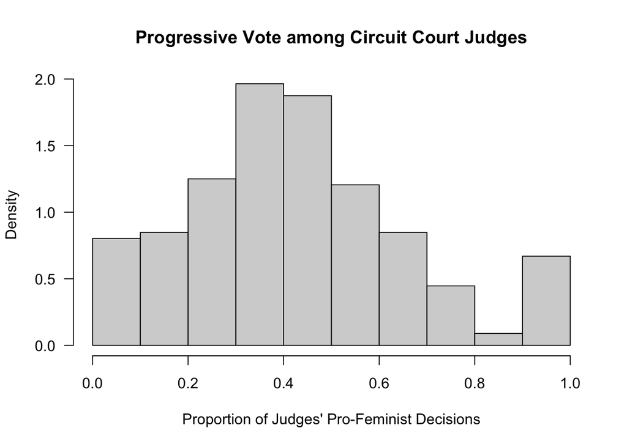

**Number of judges with `progressive_vote` == 1**

```
## [1] 14
```

**Number of judges with `progressive_vote` == 0**

```
## [1] 17
```

Number of judges by partisanship and progressive vote

|  | Progressive Vote = 1 | Progressive Vote = 0 | Row Total |
| --- | --- | --- | --- |
| Democrat | 8 | 8 | 16 |
| Republican | 6 | 9 | 15 |
| Sum | 14 | 17 | 31 |

## Question 3 (20 points)

Next, we consider differences between some groups.

- Create a new factor variable called `judges$gender_party` that takes the following 4 categories: (3 points)
  - `"Dem.Woman"` for women appointed by Democratic presidents
  - `"Rep.Woman"` for women appointed by Republican presidents
  - `"Dem.Man"` for men appointed by Democratic presidents
  - `"Rep.Man"` for men appointed by Republican presidents
- Get the the number of observations in each of the 4 categories in the variable `gender_party`. (*1 point*)
- Use `tapply` to calculate the mean of `progressive_vote` in each of these groups and save this vector as `gender_party_means`. Plot these means using a **barplot**. (*5 points*)
- In addition to the barplot, do the following. For each of the four groups defined by gender and partisanship (Republican men, Republican women, Democratic men and Democratic women), create a **boxplot** using a single command that illustrates the differences in `progressive_vote` (Hint: section 3.3.3 in QSS can be helpful here). (*5 points*)

*Note: If you want to change the location of the boxplot labels on the x axis you can use the `par(mgp = c(3,1.5,0))` function before running the `boxplot()` function (You can, but do *not have* to do that). The `mgp` argument sets the axis label locations. The first argument specifies the location of the labels (i.e. xlab and ylab in plot), the second argument the tick-mark labels, and the third argument the tick marks. The default is c(3, 1, 0).

- Briefly interpret the results from the barplot and boxplot by answering the following questions.
  - Do any of the results surprise you? (*1 point*)
  - Does it appear that partisanship, gender, or both contribute to progressive voting patterns? (*2 points*)
  - Should we interpret any of these effects causally? Why or why not? (*3 points*)

## Answer 3

**Number of observations in each category of the variable `gender_party`**

```
##
##   Dem.Man Dem.Woman   Rep.Man Rep.Woman
##        76        27       110        11
```

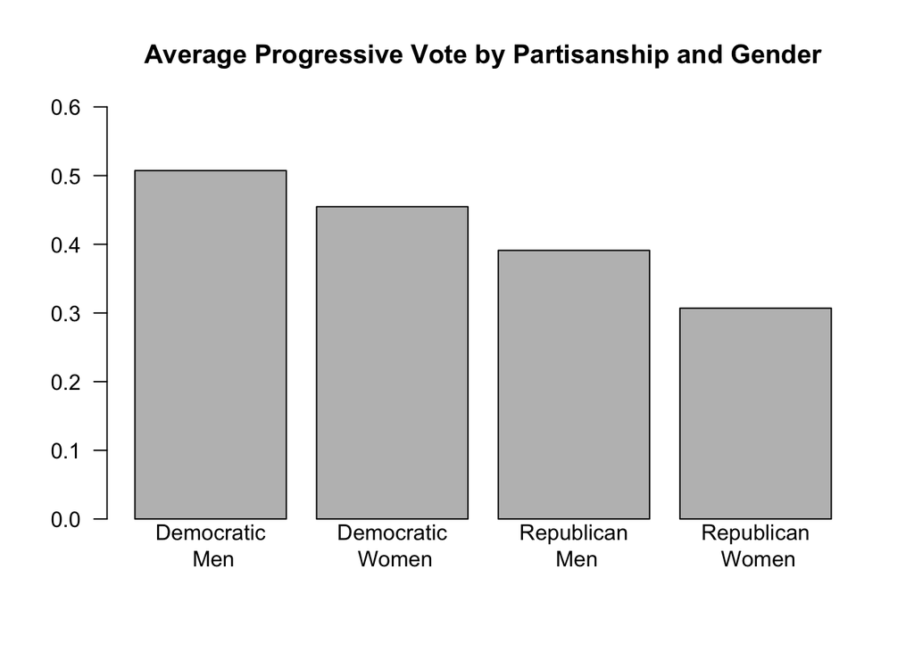

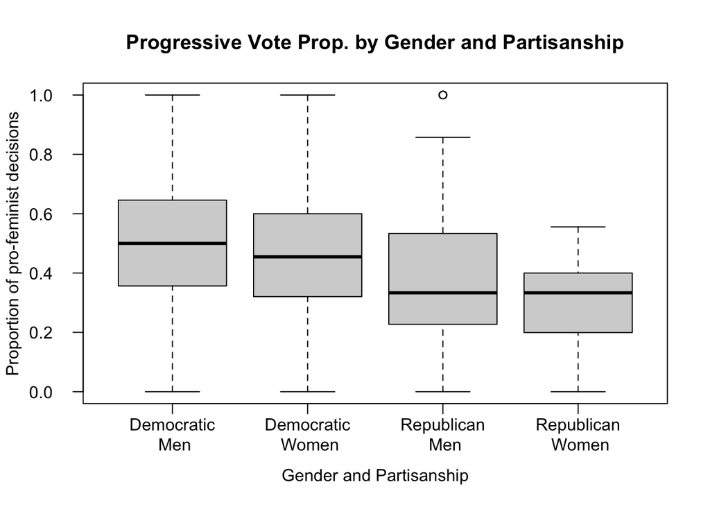

## Question 4 (25 points)

What is the difference in the proportion of pro-feminist decisions between judges who have at least one daughter and those who do not have any daughters?

- To compute this difference, first create a variable called `judges$any_girls` that is 1 when the judge has at least 1 girl and 0 otherwise. (*4 points*)
- Then, create a subset of the data called `parents` that contains judges that have at least one *child* (no matter whether boy or a girl). (*3 points*)
- Create an object called `ate` (for sample average treatment effect) that is the difference in means of `progressive_vote` between judges that have at least *one girl* versus those that have *no girls* among those judges with any children. (*3 points*)
- Provide a concise discussion of your findings in the text. In addition, answer the following questions:
  - What assumptions are required for us to interpret this difference as an estimate of a causal effect? (*5 points*)
  - Are these assumptions plausible? Under what circumstances would any of these assumptions be violated? Note: it is sufficient to discuss one assumption. (*10 points*)
    - Think about under what circumstances (or assumptions) can we talk about causal effects?
    - Did the decision to run this analysis only among those judges, who had at least one child and not among the full sample, which includes those with no children at all, makes it more plausible to talk about causal effects?
    - Further, can you think about the existence of any potential confounding factors? Should we, for example, worry about the *number of children* to be a possible confounder? If yes discuss why. If no, discuss why not.

## Answer 4

**For your information: summary of the variable `any_girls`**

```
##    Min. 1st Qu.  Median    Mean 3rd Qu.    Max.
##  0.0000  0.0000  1.0000  0.7232  1.0000  1.0000
```

**For your information: the dimensions of the `parents` dataset**

```
## [1] 199  15
```

**Sample average treatment effect of having at least 1 girl**

```
##         1
## 0.1101192
```

## Question 5 (20 points)

Given that the number of children might be a confounder for the relationship between number of girls and voting, let’s estimate the effects using statistical control for the number of children using the following steps:

- Create one subset of the data called `girls_123` that restricts to judges with one, two or three children AND have at least one girl. (*2 points*)
- Create another subset of the data called `nogirls_123` that restricts to judges with one, two or three children and have no girls. (*2 points*)
- Calculate the mean of `progressive_vote` within levels of the variable numbers of kids (`num_kids`) for each of these subsets. Save these vectors as `girls_vote_by_nkids` and `nogirls_vote_by_nkids`. (*4 points*)
- Use these two vectors to estimate the sample average treatment effect within levels, saving this vector as `ate_nkids`. (*5 points*)
- Answer the following questions in the text:
  - Are these estimated effects largely similar or largely different than what you found using all of the data? (*1 point*)
  - What assumption do you need to make to interpret these effects causally? (*2 points*)
  - Do you think it is plausible in this case? (*4 points*)

## Answer 5

**For your information: dimensions of the dataset `girls_123`**

```
## [1] 118  15
```

**For your information: dimensions of the dataset `nogirls_123`**

```
## [1] 34 15
```

**Sample average treatment effect of having at least one girl by family size (justices with 1, 2, or 3 kids)**

```
##      one child   two children three children
##      0.2408984      0.0847949      0.1893141
```

## Bonus question 1 (15 points)

Let’s consider the design of this study. The original authors assume that, conditional on the number of children a judge has, the number of daughters is random (as we did in question 5).

- Check the validity of this assumption. If this assumption is true, half of a judge’s children should be female, on average. A deviation from this proportion could indicate that a gender preference among judges due to a stopping rule such as “have children until we get one girl,” which would violate the randomization assumption.
  - One way to approach this task is to analyze the average gender distributions for judges separately by the number of children they have. We can find the average number of girls (or boys, equivalently) for judges with 1, 2, 3 children separately. Hopefully this reminds you of `tapply()`! (*3 points*)
  - Alternatively you can first calculate the proportion of girls a judge has (divide the number of girls by the number of total kids a judge has). Then find the average proportion of girls by family type (the average proportion of girls among judges with 1, 2 or 3 kids). (*3 points*)
  - Create a barplot that plots these proportions on the y-axis with the number of children on the x-axis. This barplot should have: (*4 points*)
    - informative labels on each axis
    - a y-axis range that runs from 0 to 1
    - a horizontal line at 0.5 to compare against.

Answer the following questions in the text:

- Is the assumption that the number of daughters is random reasonable? (*1 points*)
- Is there a scenario under which this assumption can be violated? (*2 points*)
- Do the data support the assumption? (*1 point*)
- Investigating the barplot, does it appear that there is strong gender preference/selection happening among judges? (*1 point*)

## Answer bonus question 1

*Do not forget to focus on the subset of judges with at least one child!*

**Average number of girls by family type (number of kids)**

```
##         1         2         3         4         5         6         7         8
## 0.5714286 1.0129870 1.5000000 1.9000000 2.6363636 2.3333333 4.0000000 4.0000000
##         9
## 5.0000000
```

**Average *proportion* of girls by family type (number of kids)**

```
##         1         2         3         4         5         6         7         8
## 0.5714286 0.5064935 0.5000000 0.4750000 0.5272727 0.3888889 0.5714286 0.5000000
##         9
## 0.5555556
```

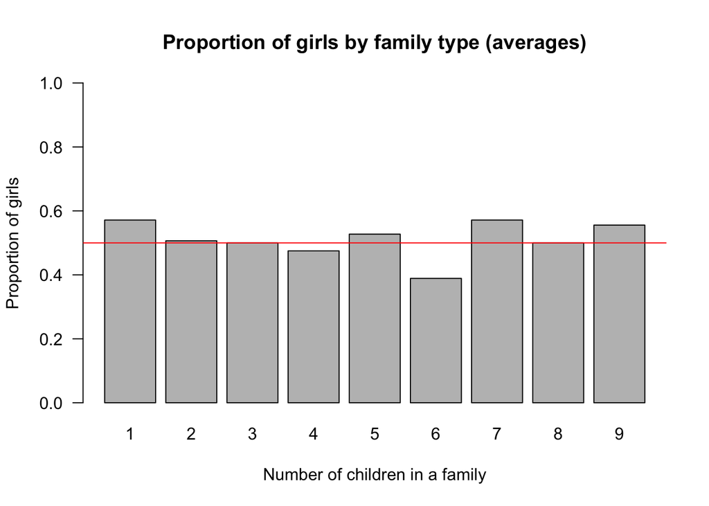

## Evaluation

- 5 questions for a total of 100 points
- 1 bonus question for 15 points